# Analysis on SeedPred dataset

### Passabì Daniele

#### Matricola 221229

## Assignment

Analyse the dataset *SeedPred* contained in the package `emdbook`, data on seed predation from Duncan and Duncan (2000) that quantify how many times seeds of two different species disappeared (presumably taken by seed predators) from observation stations in Kibale National Park, Uganda. The two species (actually the smallest- and largest-seeded species of a set of eight species) are *Polyscias fulva* (`pol`: seed mass < 0.01 g) and *Pseudospondias microcarpa* (`psd`: seed mass 50 g).

The main questions to address are: does the probability of seed removal vary as a function of distance from the forest edge (10 or 25 m)? Does it depend on species, possibly as a function of seed mass? On time?

It must be remembered that the numbers of seeds present in each location is small: 5 initially, then fewer as some are predated. The variable `available` indicates how many seeds were available at each time and station to be predated; of course, the observations with `available=0` do not give any information. Hence, the first question to address is the distribution of seeds removed; can it be fitted with the binomial distribution?

The book by Bolker gives many ideas about the analysis, but of course I expect that you develop your own code.

## Libraries and setup

First, we import the libraries needed for the study and set the variables that we will use frequently during the analysis.

```r
# LIBRARIES
library(emdbook)    # dataset library
library(DT)         # nicer display of dataframes
library(tidyverse)
library(ggplot2)    # plotting graphs
library(hrbrthemes) # theme for plotting
library(cowplot)    # useful for plots side by side

# PLOT COLORS
general_col = "#9792E3"
secondary_col = "#554DD1"
pol_col = "#FF7477"
psd_col = "#9CF6F6"
significant_col = "#70AE6E"
not_significant_col = "#F4743B"

# LOCAL LANGUAGE
Sys.setlocale("LC_ALL", "English") # we want the plots to be in English
```

## The dataset

Information about the variables used in the dataset is reported, so that we can understand in detail what the data is telling us.

```r
df = SeedPred
```

- `station` a factor specifying the station number
- `species` a factor with levels `abz`, `cd`, `cor`, `dio`, `mmu`, `pol`, `psd`, `uva`
- `date` sample date
- `seeds` number of seeds present
- `tcum` cumulative time elapsed
- `tint` time since last sample
- `taken` seeds removed since last sample
- `dist` distance from forest edge (m)
- `available` how many seeds were available at each time and station to be predated

```r
# what are the types of the columns?
glimpse(df)
```

```
## Rows: 11,803
## Columns: 9
## $ station   <fct> 1, 1, 1, 1, 1, 1, 1, 1, 1, 1, 1, 1, 1, 1, 1, 1, 1, 1, 1, ...
## $ dist      <fct> 10, 10, 10, 10, 10, 10, 10, 10, 10, 10, 10, 10, 10, 10, 1...
## $ species   <fct> psd, psd, psd, psd, psd, psd, psd, psd, psd, psd, psd, ps...
## $ date      <date> 1999-03-25, 1999-03-28, 1999-04-04, 1999-04-11, 1999-04-...
## $ seeds     <int> 5, 5, 5, 5, 0, 0, 0, 0, 0, 0, 0, 0, 0, 0, 0, 0, 0, 0, 0, ...
## $ tcum      <dbl> 0, 3, 10, 17, 24, 31, 39, 46, 53, 60, 67, 74, 80, 87, 94,...
## $ tint      <dbl> NA, 3, 7, 7, 7, 7, 8, 7, 7, 7, 7, 7, 6, 7, 7, 8, 6, 7, 7,...
## $ taken     <int> NA, 0, 0, 0, 5, 0, 0, 0, 0, 0, 0, 0, 0, 0, 0, 0, 0, 0, 0,...
## $ available <int> NA, 5, 5, 5, 5, 0, 0, 0, 0, 0, 0, 0, 0, 0, 0, 0, 0, 0, 0,...
```

```r
# exploration of initial dataframe
datatable(df, rownames = FALSE)
```

| station | dist | species | date | seeds | tcum | tint | taken | available |
| --- | --- | --- | --- | --- | --- | --- | --- | --- |
| 1 | 10 | psd | 1999-03-25 | 5 | 0 |  |  |  |
| 1 | 10 | psd | 1999-03-28 | 5 | 3 | 3 | 0 | 5 |
| 1 | 10 | psd | 1999-04-04 | 5 | 10 | 7 | 0 | 5 |
| 1 | 10 | psd | 1999-04-11 | 5 | 17 | 7 | 0 | 5 |
| 1 | 10 | psd | 1999-04-18 | 0 | 24 | 7 | 5 | 5 |
| 1 | 10 | psd | 1999-04-25 | 0 | 31 | 7 | 0 | 0 |
| 1 | 10 | psd | 1999-05-03 | 0 | 39 | 8 | 0 | 0 |
| 1 | 10 | psd | 1999-05-10 | 0 | 46 | 7 | 0 | 0 |
| 1 | 10 | psd | 1999-05-17 | 0 | 53 | 7 | 0 | 0 |
| 1 | 10 | psd | 1999-05-24 | 0 | 60 | 7 | 0 | 0 |

[output cut: 11793 more lines]

Although there are only two possible values of distance from the forest edge (10 and 25), they still represent a quantity. It is better to convert the column `dist` in numerical form. Furthermore, we can notice some missing values.

### Cleaning the dataset

- We convert the column `dist` from factors to numeric
- We keep only the information about the two species we are interested in: `pol` and `psd`
- We remove the rows where `available=0` or `NA`, as they do not provide any information

```r
df$dist = as.numeric(as.character(df$dist))

df = df[df$species == "pol" | df$species == "psd",] # keep the two species
df = df[df$available != 0 & !is.na(df$available),]  # remove rows where available = 0 or NA
df_clean = df[!is.na(df$seeds),]                    # remove rows where seeds is NA

datatable(df_clean, rownames = FALSE)
```

| station | dist | species | date | seeds | tcum | tint | taken | available |
| --- | --- | --- | --- | --- | --- | --- | --- | --- |
| 1 | 10 | psd | 1999-03-28 | 5 | 3 | 3 | 0 | 5 |
| 1 | 10 | psd | 1999-04-04 | 5 | 10 | 7 | 0 | 5 |
| 1 | 10 | psd | 1999-04-11 | 5 | 17 | 7 | 0 | 5 |
| 1 | 10 | psd | 1999-04-18 | 0 | 24 | 7 | 5 | 5 |
| 3 | 10 | pol | 1999-03-28 | 5 | 3 | 3 | 0 | 5 |
| 3 | 10 | pol | 1999-04-04 | 3 | 10 | 7 | 2 | 5 |
| 3 | 10 | pol | 1999-04-11 | 3 | 17 | 7 | 0 | 3 |
| 3 | 10 | pol | 1999-04-18 | 1 | 24 | 7 | 2 | 3 |
| 3 | 10 | pol | 1999-04-25 | 0 | 31 | 7 | 1 | 1 |
| 9 | 10 | psd | 1999-03-28 | 5 | 3 | 3 | 0 | 5 |

[output cut: 977 more lines]

## Exploratory analysis

Before answering the questions, let’s understand what data we’re dealing with. A small exploratory analysis of the cleaned dataset follows.

### *How many entries for each species and distances?*

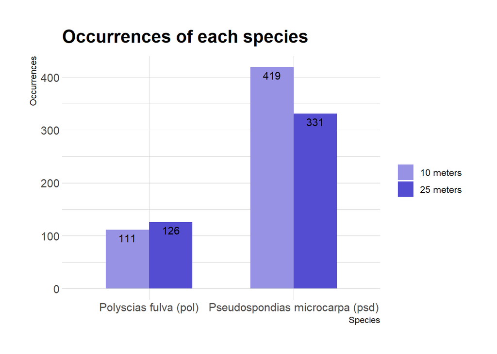

```r
# Find the frequencies of the species
df_freqs = df_clean %>%
  group_by(species, dist) %>%
  summarise(n = n())

# Nicer names
df_freqs$species = ifelse(df_freqs$species == "pol", "Polyscias fulva (pol)", "Pseudospondias microcarpa (psd)")
df_freqs$dist = ifelse(df_freqs$dist == 10, "10 meters", "25 meters")

# Plot the results
ggplot(df_freqs, aes(x=species, y=n, fill=dist)) +
  geom_bar(stat = "identity", width = 0.6, position = position_dodge()) +
  theme_ipsum() +
  labs(title = "Occurrences of each species",
       x = "Species", y = "Occurrences") +
  scale_fill_manual("legend", values = c("10 meters" = general_col, "25 meters" = secondary_col)) +
  theme(legend.title = element_blank()) +
  geom_text(aes(label=n), position=position_dodge(width=0.6), vjust=1.5)
```

### *What happens to seeds over time?*

A simple plot of the data, for one specific station, seed type and distance.

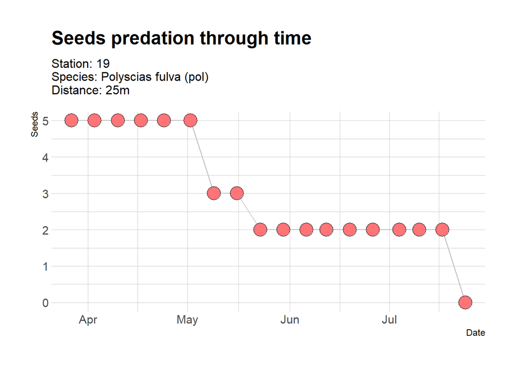

```r
example_station = 19
example_distance = 25

df_stat_65 = df_clean[df_clean$station == example_station & df_clean$dist == example_distance,]

df_stat_65 %>%
  ggplot( aes(x=date, y=seeds)) +
    geom_line(color="grey") +
    geom_point(shape=21, color="black", fill=pol_col, size=6) +
    theme_ipsum() +
    labs(title = "Seeds predation through time",
         subtitle = "Station: 19\nSpecies: Polyscias fulva (pol)\nDistance: 25m",
         x = "Date", y = "Seeds")
```

It is possible to notice from the chart that the seeds initially available are 5. Every 7 days the number of available seeds is checked and updated. This is done for a certain period of time or until there are no more seeds available, as in the example shown.

The graph shown does not provide us with information about the overall trend in the data. Let’s try to generalize it.

```r
# CASE 1: pol, 10
df_pol_10 = df_clean[df_clean$species == "pol" & df_clean$dist == 10,]

# count how many measuraments there are for each date
df_temp_1 = df_pol_10 %>%
  count(date)

# count the total number of seeds for each date
df_temp_2 = df_pol_10 %>%
  group_by(date) %>%
  summarise(total_seeds = sum(seeds))

# merge the information to obtain mean seeds available
df_temp_2$n = df_temp_1$n
df_temp_2$mean_seeds = df_temp_2$total_seeds / df_temp_2$n

df_pol_10 = df_temp_2

###

# CASE 2: pol, 25
df_pol_25 = df_clean[df_clean$species == "pol" & df_clean$dist == 25,]

# count how many measuraments there are for each date
df_temp_1 = df_pol_25 %>%
  count(date)

# count the total number of seeds for each date
df_temp_2 = df_pol_25 %>%
  group_by(date) %>%
  summarise(total_seeds = sum(seeds))

# merge the information to obtain mean seeds available
df_temp_2$n = df_temp_1$n
df_temp_2$mean_seeds = df_temp_2$total_seeds / df_temp_2$n

df_pol_25 = df_temp_2

###

# CASE 3: psd, 10
df_psd_10 = df_clean[df_clean$species == "psd" & df_clean$dist == 10,]

# count how many measuraments there are for each date
df_temp_1 = df_psd_10 %>%
  count(date)

# count the total number of seeds for each date
df_temp_2 = df_psd_10 %>%
  group_by(date) %>%
  summarise(total_seeds = sum(seeds))

# merge the information to obtain mean seeds available
df_temp_2$n = df_temp_1$n
df_temp_2$mean_seeds = df_temp_2$total_seeds / df_temp_2$n

df_psd_10 = df_temp_2

###

# CASE 4: psd, 25
df_psd_25 = df_clean[df_clean$species == "psd" & df_clean$dist == 25,]

# count how many measuraments there are for each date
df_temp_1 = df_psd_25 %>%
  count(date)

# count the total number of seeds for each date
df_temp_2 = df_psd_25 %>%
  group_by(date) %>%
  summarise(total_seeds = sum(seeds))

# merge the information to obtain mean seeds available
df_temp_2$n = df_temp_1$n
df_temp_2$mean_seeds = df_temp_2$total_seeds / df_temp_2$n

df_psd_25 = df_temp_2
```

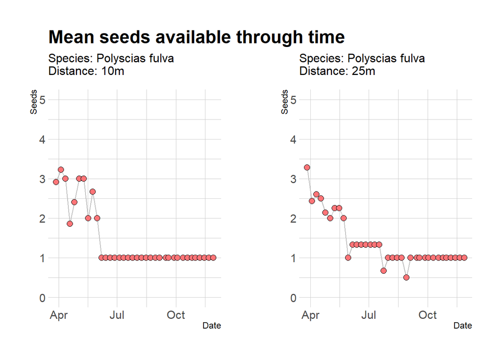

```r
# Now we plot

pol1 = df_pol_10 %>%
  ggplot( aes(x=date, y=mean_seeds)) +
    geom_line(color="grey") +
    geom_point(shape=21, color="black", fill=pol_col, size=2.5) +
    ylim(0, 5) +
    theme_ipsum() +
    labs(title = "Mean seeds available through time",
         subtitle = "Species: Polyscias fulva\nDistance: 10m",
         x = "Date", y = "Seeds")

pol2 = df_pol_25 %>%
  ggplot( aes(x=date, y=mean_seeds)) +
    geom_line(color="grey") +
    geom_point(shape=21, color="black", fill=pol_col, size=2.5) +
    ylim(0, 5) +
    theme_ipsum() +
    labs(title = "",
         subtitle = "Species: Polyscias fulva\nDistance: 25m",
         x = "Date", y = "Seeds")

psd1 = df_psd_10 %>%
  ggplot( aes(x=date, y=mean_seeds)) +
    geom_line(color="grey") +
    geom_point(shape=21, color="black", fill=psd_col, size=2.5) +
    ylim(0, 5) +
    theme_ipsum() +
    labs(title = "Mean seeds available through time",
         subtitle = "Species: Pseudospondias microcarpa\nDistance: 10m",
         x = "Date", y = "Seeds")

psd2 = df_psd_25 %>%
  ggplot( aes(x=date, y=mean_seeds)) +
    geom_line(color="grey") +
    geom_point(shape=21, color="black", fill=psd_col, size=2.5) +
    ylim(0, 5) +
    theme_ipsum() +
    labs(title = "",
         subtitle = "Species: Pseudospondias microcarpa\nDistance: 25m",
         x = "Date", y = "Seeds")

plot_grid(pol1, pol2, labels = "", ncol = 2)
```

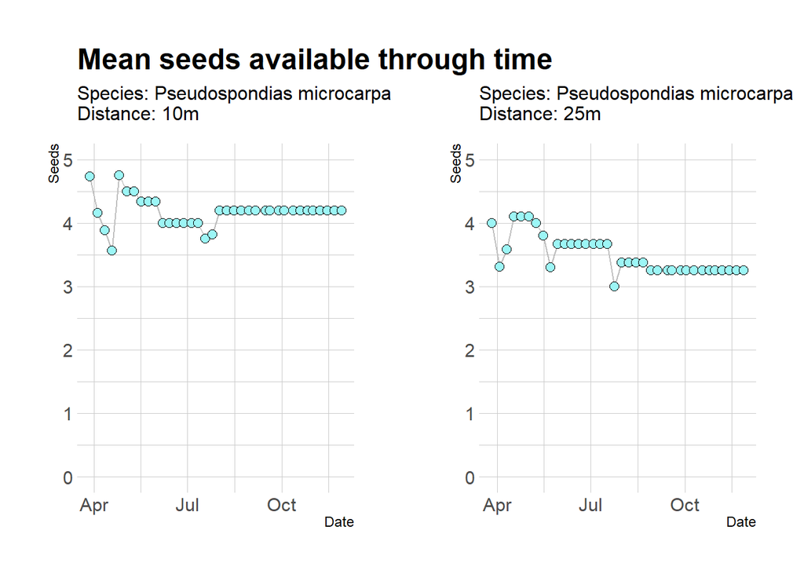

```r
plot_grid(psd1, psd2, labels = "", ncol = 2)
```

From these simple graphs we can see that seed species seems to strongly influence the average number of available seeds. The distance, on the other hand, seems to be relevant only for the Pseudospondias microcarpa seed.

## Binomial Distribution

### Can the *distribution of seeds removed* be fitted with the *binomial distribution*?

We can interpret in 2 ways our data.

**CASE A**

For each `date` *d*, the `available` seeds can either be predated or not (we do not consider each individual seed).

We create a new column, `seeds_rem`, based on `taken` column. `seeds_rem` is a boolean column where:

- `TRUE` indicates that any number of seeds were predated
- `FALSE` indicates that no seeds were predated

```r
df_clean$seeds_rem = ifelse(df_clean$taken == 0, FALSE, TRUE)

datatable(df_clean, rownames = FALSE)
```

| station | dist | species | date | seeds | tcum | tint | taken | available | seeds_rem |
| --- | --- | --- | --- | --- | --- | --- | --- | --- | --- |
| 1 | 10 | psd | 1999-03-28 | 5 | 3 | 3 | 0 | 5 | False |
| 1 | 10 | psd | 1999-04-04 | 5 | 10 | 7 | 0 | 5 | False |
| 1 | 10 | psd | 1999-04-11 | 5 | 17 | 7 | 0 | 5 | False |
| 1 | 10 | psd | 1999-04-18 | 0 | 24 | 7 | 5 | 5 | True |
| 3 | 10 | pol | 1999-03-28 | 5 | 3 | 3 | 0 | 5 | False |
| 3 | 10 | pol | 1999-04-04 | 3 | 10 | 7 | 2 | 5 | True |
| 3 | 10 | pol | 1999-04-11 | 3 | 17 | 7 | 0 | 3 | False |
| 3 | 10 | pol | 1999-04-18 | 1 | 24 | 7 | 2 | 3 | True |
| 3 | 10 | pol | 1999-04-25 | 0 | 31 | 7 | 1 | 1 | True |
| 9 | 10 | psd | 1999-03-28 | 5 | 3 | 3 | 0 | 5 | False |

[output cut: 977 more lines]

```r
summary(df_clean$seeds_rem)
```

```
##    Mode   FALSE    TRUE
## logical     890      97
```

By simply using the `summary` function we can obtain all the information we need for the binomial distribution.

```r
successes = 97
n = 890 + 97
emp_prob = successes/n

message("Number of trials: ", n, "\nProbability of seeds removal: ", round(emp_prob,4))
```

```
## Number of trials: 987
## Probability of seeds removal: 0.0983
```

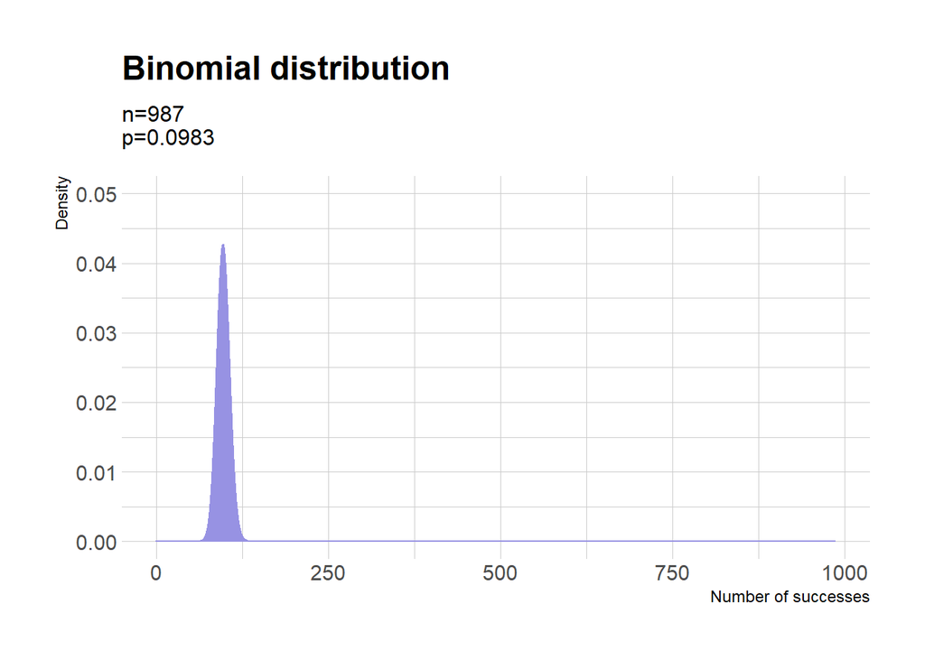

```r
x1 = 0:n
df = data.frame(x = x1, y = dbinom(x1, n, emp_prob))

plot_full = ggplot(df, aes(x = x, y = y)) +
  geom_bar(stat = "identity", col = general_col, fill = general_col) +
  xlab("Number of successes") +
  ylab("Density") +
  ylim(0,0.05) +
  labs(title = "Binomial distribution",
       subtitle = "n=987\np=0.0983") +
  theme_ipsum()

plot_zoom = ggplot(df, aes(x = x, y = y)) +
  geom_bar(stat = "identity", col = general_col, fill = general_col) +
  xlab("Number of successes") +
  xlim(50,150) +
  ylab("Density") +
  ylim(0,0.05) +
  labs(title = "Binomial distribution",
       subtitle = "n=987\np=0.0983") +
  theme_ipsum()

plot_full
```

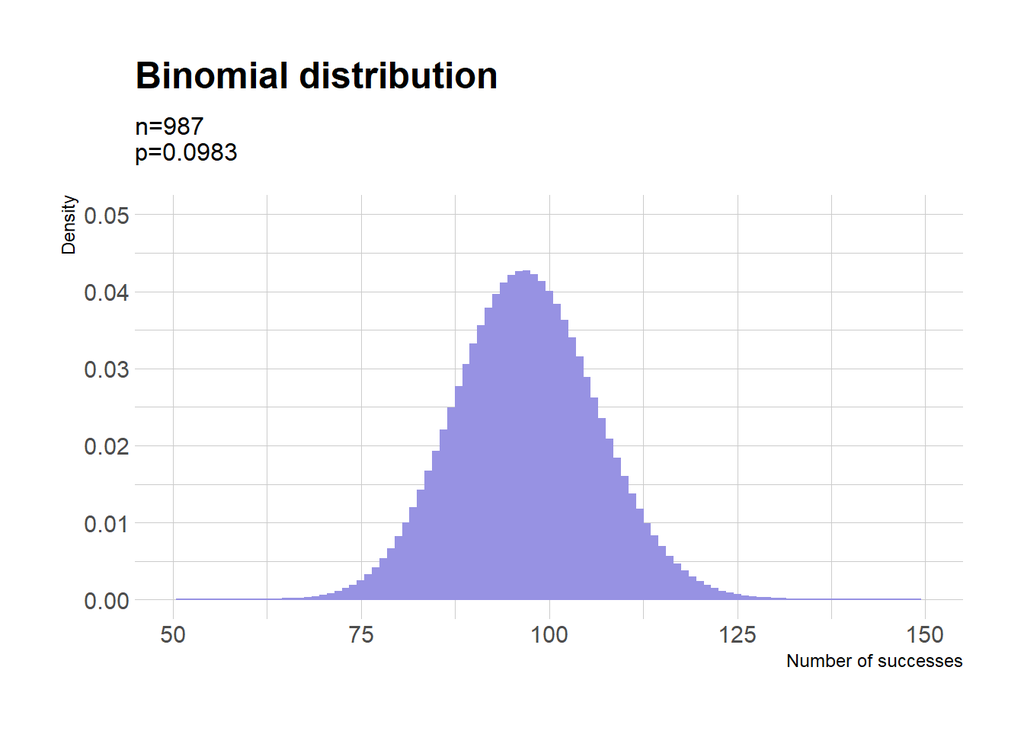

```r
plot_zoom
```

**CASE B**

We consider each seed individually. The focus lies on the columns `taken` and `available`.

As done for the last case, we obtain the necessary information for the binomial distribution.

```r
successes = sum(df_clean$taken)
n = sum(df_clean$available)
emp_prob = successes/n

message("Number of trials: ", n, "\nNumber of successes: ", successes, "\nProbability of seeds removal: ", round(emp_prob,4))
```

```
## Number of trials: 3620
## Number of successes: 248
## Probability of seeds removal: 0.0685
```

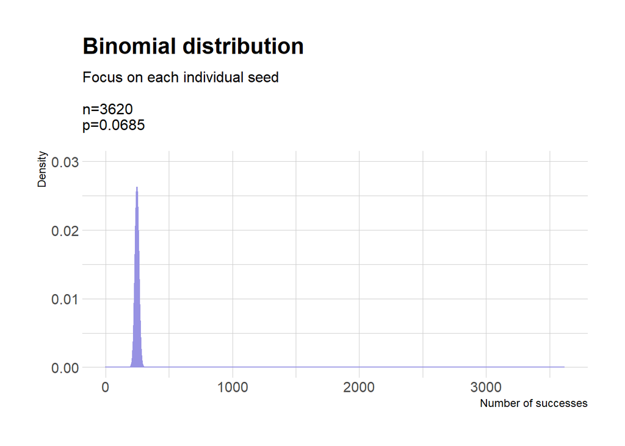

```r
x1 = 0:n
df = data.frame(x = x1, y = dbinom(x1, n, emp_prob))

plot_full = ggplot(df, aes(x = x, y = y)) +
  geom_bar(stat = "identity", col = general_col, fill = general_col) +
  xlab("Number of successes") +
  ylab("Density") +
  ylim(0,0.03) +
  labs(title = "Binomial distribution",
       subtitle = "Focus on each individual seed\n\nn=3620\np=0.0685") +
  theme_ipsum()

plot_zoom = ggplot(df, aes(x = x, y = y)) +
  geom_bar(stat = "identity", col = general_col, fill = general_col) +
  xlab("Number of successes") +
  xlim(150,350) +
  ylab("Density") +
  ylim(0,0.03) +
  labs(title = "Binomial distribution",
       subtitle = "Focus on each individual seed\n\nn=3620\np=0.0685") +
  theme_ipsum()

plot_full
```

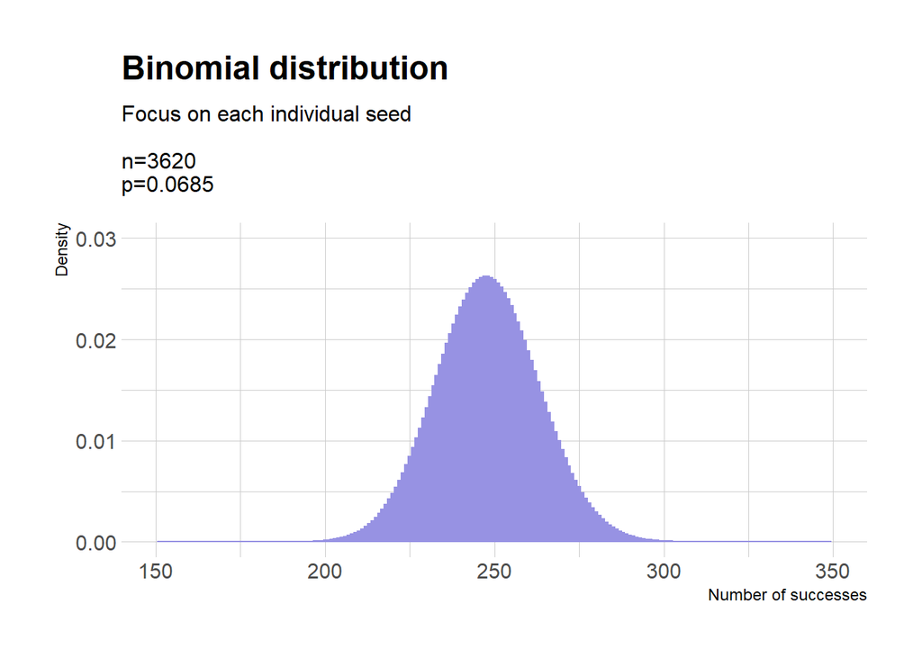

```r
plot_zoom
```

## Linear models

#### Does the *probability of seed removal* vary as a function of *distance* from the forest edge (10 or 25 m)?

#### Does it depend on *species*, possibly as a function of seed mass? On *time*?

First, we create the column with the data regarding the probability of seed removal (`p_seed_rem`).

```r
df_clean$p_seed_rem = round(df_clean$taken / df_clean$available, 4)

datatable(df_clean, rownames = FALSE)
```

| station | dist | species | date | seeds | tcum | tint | taken | available | seeds_rem | p_seed_rem |
| --- | --- | --- | --- | --- | --- | --- | --- | --- | --- | --- |
| 1 | 10 | psd | 1999-03-28 | 5 | 3 | 3 | 0 | 5 | False | 0 |
| 1 | 10 | psd | 1999-04-04 | 5 | 10 | 7 | 0 | 5 | False | 0 |
| 1 | 10 | psd | 1999-04-11 | 5 | 17 | 7 | 0 | 5 | False | 0 |
| 1 | 10 | psd | 1999-04-18 | 0 | 24 | 7 | 5 | 5 | True | 1 |
| 3 | 10 | pol | 1999-03-28 | 5 | 3 | 3 | 0 | 5 | False | 0 |
| 3 | 10 | pol | 1999-04-04 | 3 | 10 | 7 | 2 | 5 | True | 0.4 |
| 3 | 10 | pol | 1999-04-11 | 3 | 17 | 7 | 0 | 3 | False | 0 |
| 3 | 10 | pol | 1999-04-18 | 1 | 24 | 7 | 2 | 3 | True | 0.6667 |
| 3 | 10 | pol | 1999-04-25 | 0 | 31 | 7 | 1 | 1 | True | 1 |
| 9 | 10 | psd | 1999-03-28 | 5 | 3 | 3 | 0 | 5 | False | 0 |

[output cut: 977 more lines]

#### Distance

Is it significant?

First, let’s create the model.

```r
model_dist = lm(p_seed_rem~dist, data=df_clean)
```

Useful info can be obtained through the function `summary`.

```r
summary(model_dist)
```

```
##
## Call:
## lm(formula = p_seed_rem ~ dist, data = df_clean)
##
## Residuals:
##      Min       1Q   Median       3Q      Max
## -0.08045 -0.08045 -0.05610 -0.05610  0.94390
##
## Coefficients:
##              Estimate Std. Error t value Pr(>|t|)
## (Intercept) 0.0398664  0.0180150   2.213   0.0271 *
## dist        0.0016234  0.0009726   1.669   0.0954 .
## ---
## Signif. codes:  0 '***' 0.001 '**' 0.01 '*' 0.05 '.' 0.1 ' ' 1
##
## Residual standard error: 0.2285 on 985 degrees of freedom
## Multiple R-squared:  0.002821,   Adjusted R-squared:  0.001808
## F-statistic: 2.786 on 1 and 985 DF,  p-value: 0.0954
```

**`## dist 0.0016234 0.0009726 1.669 0.0954 .`**

From the result we can see how the `distance` is not that significant.

As a result, our regression line does not adequately represent the model.

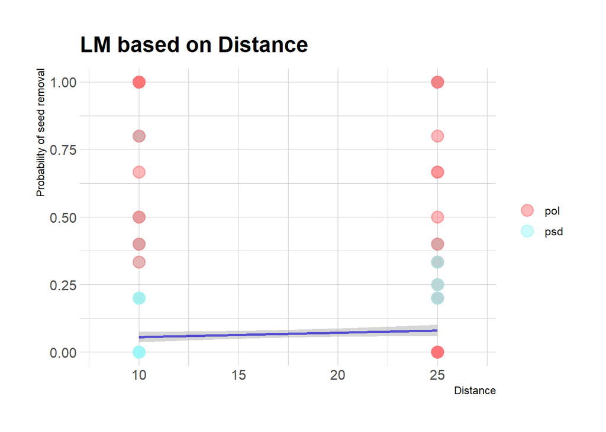

```r
# LM on DISTANCE

ggplot(df_clean, aes(x = dist, y = p_seed_rem, color = species)) +
  geom_point(
    alpha=0.5,
    size=4,
    stroke = 1
  ) +
  geom_smooth(method = "lm", formula= y~x, col = secondary_col) +
  xlim(8,27) +
  theme_ipsum() +
  scale_color_manual(values=c(pol_col, psd_col)) +
  labs(title = "LM based on Distance",
       x = "Distance",
       y = "Probability of seed removal") +
  theme(legend.title = element_blank())
```

What we can try to do is split the two datasets by `species`. From the plots obtained in the exploratory analysis it appeared that the distance was more significant for the *psd* species.

```r
# We create the sub-datasets
df_pol = df_clean[df_clean$species == "pol",]
df_psd = df_clean[df_clean$species == "psd",]

# We create two distinct linear models
model_dist_pol = lm(p_seed_rem~dist, data=df_pol)
model_dist_psd = lm(p_seed_rem~dist, data=df_psd)
```

Let’s see the results.

```r
summary(model_dist_pol)
```

```
##
## Call:
## lm(formula = p_seed_rem ~ dist, data = df_pol)
##
## Residuals:
##     Min      1Q  Median      3Q     Max
## -0.1843 -0.1843 -0.1396 -0.1396  0.8604
##
## Coefficients:
##             Estimate Std. Error t value Pr(>|t|)
## (Intercept) 0.109894   0.056923   1.931   0.0547 .
## dist        0.002975   0.002924   1.017   0.3100
## ---
## Signif. codes:  0 '***' 0.001 '**' 0.01 '*' 0.05 '.' 0.1 ' ' 1
##
## Residual standard error: 0.3369 on 235 degrees of freedom
## Multiple R-squared:  0.004386,   Adjusted R-squared:  0.0001493
## F-statistic: 1.035 on 1 and 235 DF,  p-value: 0.31
```

**`## dist 0.002975 0.002924 1.017 0.3100`**

```r
summary(model_dist_psd)
```

```
##
## Call:
## lm(formula = p_seed_rem ~ dist, data = df_psd)
##
## Residuals:
##      Min       1Q   Median       3Q      Max
## -0.04094 -0.04094 -0.03397 -0.03397  0.96603
##
## Coefficients:
##              Estimate Std. Error t value Pr(>|t|)
## (Intercept) 0.0293253  0.0152861   1.918   0.0554 .
## dist        0.0004644  0.0008393   0.553   0.5802
## ---
## Signif. codes:  0 '***' 0.001 '**' 0.01 '*' 0.05 '.' 0.1 ' ' 1
##
## Residual standard error: 0.1712 on 748 degrees of freedom
## Multiple R-squared:  0.0004092,  Adjusted R-squared:  -0.0009272
## F-statistic: 0.3062 on 1 and 748 DF,  p-value: 0.5802
```

**`## dist 0.0004644 0.0008393 0.553 0.5802`**

Despite the division of the dataset, we did not achieve improvement, quite the contrary.

#### Species

Are they significant?

As before, we create the model.

```r
model_species = lm(p_seed_rem~species, data=df_clean)
```

When we use a *qualitative variable* the best way to look at the data is using `anova`.

```r
print(anova(model_species))
```

```
## Analysis of Variance Table
##
## Response: p_seed_rem
##            Df Sum Sq Mean Sq F value    Pr(>F)
## species     1  2.874 2.87353  58.097 5.855e-14 ***
## Residuals 985 48.719 0.04946
## ---
## Signif. codes:  0 '***' 0.001 '**' 0.01 '*' 0.05 '.' 0.1 ' ' 1
```

**`## species 1 2.874 2.87353 58.097 5.855e-14 ***`**

```r
summary(model_species)
```

```
##
## Call:
## lm(formula = p_seed_rem ~ species, data = df_clean)
##
## Residuals:
##      Min       1Q   Median       3Q      Max
## -0.16336 -0.03704 -0.03704 -0.03704  0.96296
##
## Coefficients:
##             Estimate Std. Error t value Pr(>|t|)
## (Intercept)  0.16336    0.01445  11.308  < 2e-16 ***
## speciespsd  -0.12632    0.01657  -7.622 5.86e-14 ***
## ---
## Signif. codes:  0 '***' 0.001 '**' 0.01 '*' 0.05 '.' 0.1 ' ' 1
##
## Residual standard error: 0.2224 on 985 degrees of freedom
## Multiple R-squared:  0.0557, Adjusted R-squared:  0.05474
## F-statistic:  58.1 on 1 and 985 DF,  p-value: 5.855e-14
```

**`## speciespsd -0.12632 0.01657 -7.622 5.86e-14 ***`**

The p-value is extremely low, so we can say with a high degree of confidence that the variable `species` is relevant. This result confirms what we hypothesized in the exploratory analysis.

We can get more useful information through the use of the *residuals plot*.

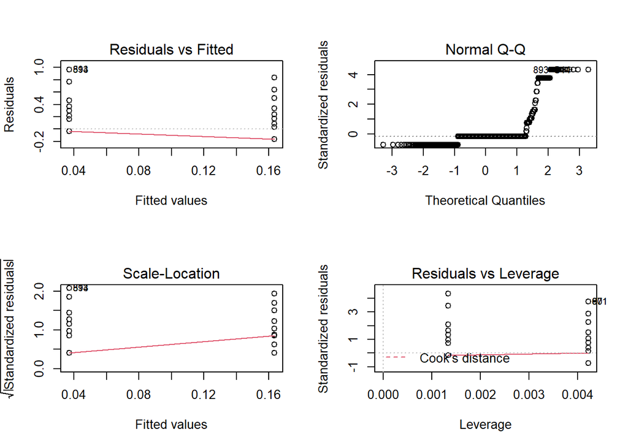

```r
par(mfrow = c(2,2))
plot(model_species)
```

It is not necessary to analyze in depth all the graphs to understand that the model is not extremely accurate.

In the first and in the third graph we immediately notice how the data is not homogeneously distributed. In the second one it is obvious that a normal distribution is not followed. The fourth does not detect the presence of outliers.

#### Time

Is it significant? We use the variable `tcum`, the cumulative time elapsed (expressed in days).

```r
model_time = lm(p_seed_rem~tcum, data=df_clean)
summary(model_time)
```

```
##
## Call:
## lm(formula = p_seed_rem ~ tcum, data = df_clean)
##
## Residuals:
##      Min       1Q   Median       3Q      Max
## -0.15552 -0.11219 -0.05341  0.01438  0.97834
##
## Coefficients:
##               Estimate Std. Error t value Pr(>|t|)
## (Intercept)  1.581e-01  1.195e-02  13.228   <2e-16 ***
## tcum        -8.581e-04  9.175e-05  -9.352   <2e-16 ***
## ---
## Signif. codes:  0 '***' 0.001 '**' 0.01 '*' 0.05 '.' 0.1 ' ' 1
##
## Residual standard error: 0.2193 on 985 degrees of freedom
## Multiple R-squared:  0.08155,    Adjusted R-squared:  0.08062
## F-statistic: 87.46 on 1 and 985 DF,  p-value: < 2.2e-16
```

**`## tcum -8.581e-04 9.175e-05 -9.352 <2e-16 ***`**

In this case, as in the previous one, we get a very low p-value and we can say that the variable `tcum` is significant.

Since we are working with a quantitative variable, it’s easy to plot our regression line.

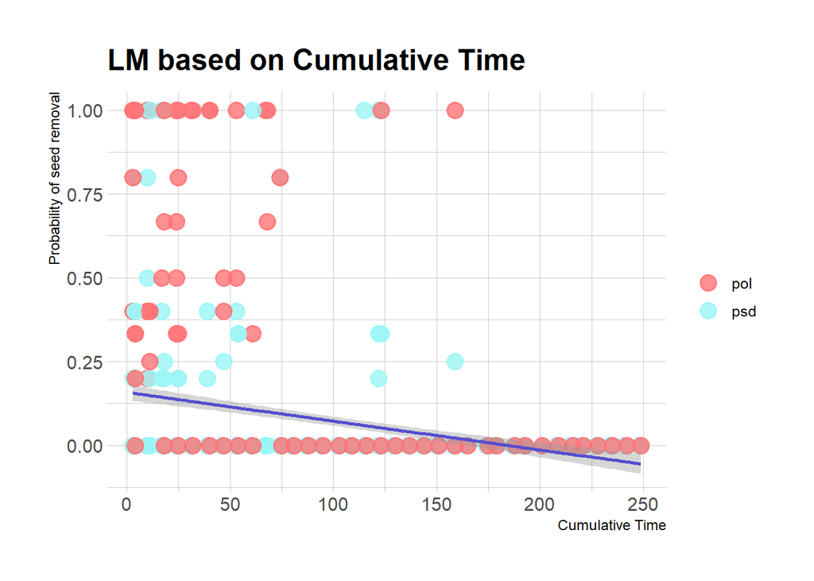

```r
# LM on CUMULATIVE TIME

ggplot(df_clean, aes(x = tcum, y = p_seed_rem, color = species)) +
  geom_point(
    alpha=0.8,
    size=4,
    stroke = 1
  ) +
  geom_smooth(method = "lm", formula= y~x, col = secondary_col) +
  theme_ipsum() +
  scale_color_manual(values=c(pol_col, psd_col)) +
  labs(title = "LM based on Cumulative Time",
       x = "Cumulative Time",
       y = "Probability of seed removal") +
  theme(legend.title = element_blank())
```

It is easy to see how difficult it is for a straight line to follow the trend of the data. Let’s try a **polynomial model**.

```r
# Poly of grade 2

model_time_poly2 = lm(p_seed_rem~poly(tcum,2), data=df_clean)
summary(model_time_poly2)
```

```
##
## Call:
## lm(formula = p_seed_rem ~ poly(tcum, 2), data = df_clean)
##
## Residuals:
##      Min       1Q   Median       3Q      Max
## -0.20870 -0.09838 -0.02116  0.00631  1.00951
##
## Coefficients:
##                 Estimate Std. Error t value Pr(>|t|)
## (Intercept)     0.067376   0.006887   9.783  < 2e-16 ***
## poly(tcum, 2)1 -2.051204   0.216365  -9.480  < 2e-16 ***
## poly(tcum, 2)2  1.149148   0.216365   5.311 1.35e-07 ***
## ---
## Signif. codes:  0 '***' 0.001 '**' 0.01 '*' 0.05 '.' 0.1 ' ' 1
##
## Residual standard error: 0.2164 on 984 degrees of freedom
## Multiple R-squared:  0.1071, Adjusted R-squared:  0.1053
## F-statistic: 59.04 on 2 and 984 DF,  p-value: < 2.2e-16
```

```r
# Poly of grade 3

model_time_poly3 = lm(p_seed_rem~poly(tcum,3), data=df_clean)
summary(model_time_poly3)
```

```
##
## Call:
## lm(formula = p_seed_rem ~ poly(tcum, 3), data = df_clean)
##
## Residuals:
##      Min       1Q   Median       3Q      Max
## -0.23466 -0.07812 -0.01347 -0.01026  0.98882
##
## Coefficients:
##                 Estimate Std. Error t value Pr(>|t|)
## (Intercept)     0.067376   0.006868   9.811  < 2e-16 ***
## poly(tcum, 3)1 -2.051204   0.215756  -9.507  < 2e-16 ***
## poly(tcum, 3)2  1.149148   0.215756   5.326 1.24e-07 ***
## poly(tcum, 3)3 -0.552750   0.215756  -2.562   0.0106 *
## ---
## Signif. codes:  0 '***' 0.001 '**' 0.01 '*' 0.05 '.' 0.1 ' ' 1
##
## Residual standard error: 0.2158 on 983 degrees of freedom
## Multiple R-squared:  0.1131, Adjusted R-squared:  0.1104
## F-statistic: 41.77 on 3 and 983 DF,  p-value: < 2.2e-16
```

We can see how there are improvements over the linear model (higher R-squared values). Using a grade 2 or 3, however, leads to very similar results. We don’t use even higher grades since they bring us no benefit.

The plots of the two models follow.

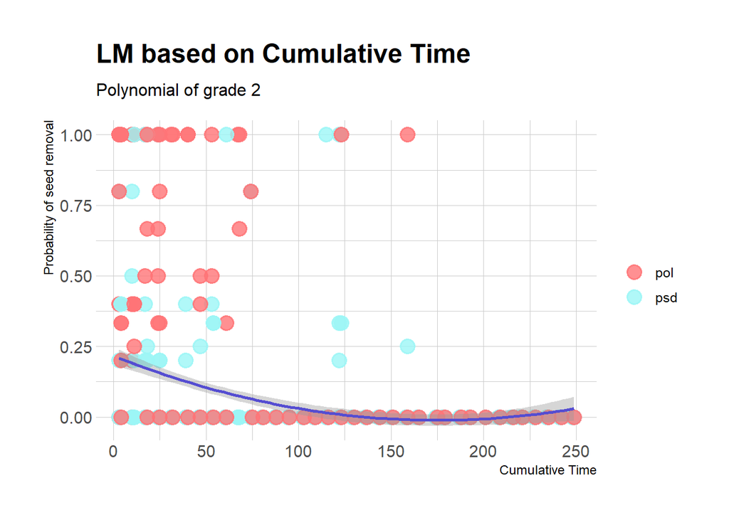

```r
# Plots of the polynomial models

# Grade 2

ggplot(df_clean, aes(x = tcum, y = p_seed_rem, color = species)) +
  geom_point(
    alpha=0.8,
    size=4,
    stroke = 1
  ) +
  geom_smooth(method = "lm", formula= y~poly(x,2), col = secondary_col) +
  theme_ipsum() +
  scale_color_manual(values=c(pol_col, psd_col)) +
  labs(title = "LM based on Cumulative Time",
       subtitle = "Polynomial of grade 2",
       x = "Cumulative Time",
       y = "Probability of seed removal") +
  theme(legend.title = element_blank())
```

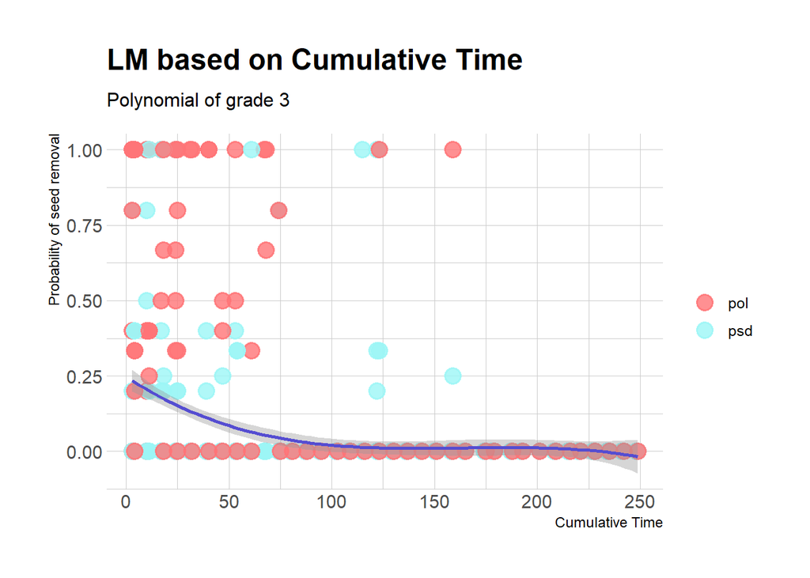

```r
# Grade 3

ggplot(df_clean, aes(x = tcum, y = p_seed_rem, color = species)) +
  geom_point(
    alpha=0.8,
    size=4,
    stroke = 1
  ) +
  geom_smooth(method = "lm", formula= y~poly(x,3), col = secondary_col) +
  theme_ipsum() +
  scale_color_manual(values=c(pol_col, psd_col)) +
  labs(title = "LM based on Cumulative Time",
       subtitle = "Polynomial of grade 3",
       x = "Cumulative Time",
       y = "Probability of seed removal") +
  theme(legend.title = element_blank())
```

Plots of the residuals of the third degree polynomial model are shown below.

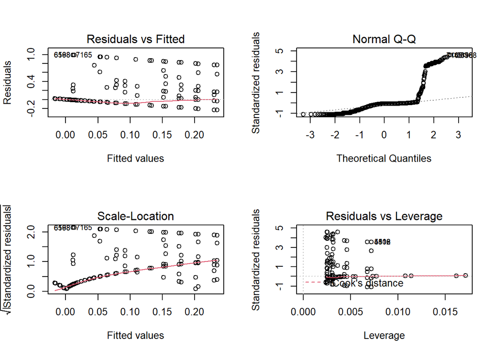

```r
par(mfrow = c(2,2))
plot(model_time_poly3)
```

The graphs seem to be a little bit nicer, even if the data still does not follow a normal distribution.

#### Date

It is reasonable to use the date, but instead of focusing on the single day, better results should be achieved using months. So, we do a little bit of data manipulation and we add the column `month` to our dataframe.

```r
df_clean$month = as.factor(months(df_clean$date))
datatable(df_clean, rownames = FALSE)
```

| station | dist | species | date | seeds | tcum | tint | taken | available | seeds_rem | p_seed_rem | month |
| --- | --- | --- | --- | --- | --- | --- | --- | --- | --- | --- | --- |
| 1 | 10 | psd | 1999-03-28 | 5 | 3 | 3 | 0 | 5 | False | 0 | March |
| 1 | 10 | psd | 1999-04-04 | 5 | 10 | 7 | 0 | 5 | False | 0 | April |
| 1 | 10 | psd | 1999-04-11 | 5 | 17 | 7 | 0 | 5 | False | 0 | April |
| 1 | 10 | psd | 1999-04-18 | 0 | 24 | 7 | 5 | 5 | True | 1 | April |
| 3 | 10 | pol | 1999-03-28 | 5 | 3 | 3 | 0 | 5 | False | 0 | March |
| 3 | 10 | pol | 1999-04-04 | 3 | 10 | 7 | 2 | 5 | True | 0.4 | April |
| 3 | 10 | pol | 1999-04-11 | 3 | 17 | 7 | 0 | 3 | False | 0 | April |
| 3 | 10 | pol | 1999-04-18 | 1 | 24 | 7 | 2 | 3 | True | 0.6667 | April |
| 3 | 10 | pol | 1999-04-25 | 0 | 31 | 7 | 1 | 1 | True | 1 | April |
| 9 | 10 | psd | 1999-03-28 | 5 | 3 | 3 | 0 | 5 | False | 0 | March |

[output cut: 977 more lines]

The `month` variable is *qualitative*, so we use `anova`.

```r
model_month = lm(p_seed_rem~month, data=df_clean)

print(anova(model_month))
```

```
## Analysis of Variance Table
##
## Response: p_seed_rem
##            Df Sum Sq Mean Sq F value    Pr(>F)
## month       8  5.956 0.74451  15.955 < 2.2e-16 ***
## Residuals 978 45.637 0.04666
## ---
## Signif. codes:  0 '***' 0.001 '**' 0.01 '*' 0.05 '.' 0.1 ' ' 1
```

**`## month 8 5.956 0.74451 15.955 < 2.2e-16 ***`**

According to the Analysis of Variance Table, the variable is significant. Let’s investigate further.

```r
summary(model_month)
```

```
##
## Call:
## lm(formula = p_seed_rem ~ month, data = df_clean)
##
## Residuals:
##      Min       1Q   Median       3Q      Max
## -0.19801 -0.06924 -0.01538  0.00000  0.98750
##
## Coefficients:
##                 Estimate Std. Error t value Pr(>|t|)
## (Intercept)     0.194475   0.016056  12.112  < 2e-16 ***
## monthAugust    -0.181975   0.026915  -6.761 2.35e-11 ***
## monthJuly      -0.151408   0.025899  -5.846 6.85e-09 ***
## monthJune      -0.179091   0.026580  -6.738 2.74e-11 ***
## monthMarch      0.003534   0.030891   0.114    0.909
## monthMay       -0.125236   0.023895  -5.241 1.96e-07 ***
## monthNovember  -0.194475   0.028519  -6.819 1.60e-11 ***
## monthOctober   -0.194475   0.026499  -7.339 4.52e-13 ***
## monthSeptember -0.194475   0.028519  -6.819 1.60e-11 ***
## ---
## Signif. codes:  0 '***' 0.001 '**' 0.01 '*' 0.05 '.' 0.1 ' ' 1
##
## Residual standard error: 0.216 on 978 degrees of freedom
## Multiple R-squared:  0.1154, Adjusted R-squared:  0.1082
## F-statistic: 15.96 on 8 and 978 DF,  p-value: < 2.2e-16
```

Our `ANOVA` results seems to be confirmed. We can see that there are significant differences between most of the months and the month taken as a reference (April). The only month with an a high p-value is March, which seems to make sense since March and April are consecutive months.

We can get even more information using `TukeyHSD`, a function that computes the *Honest significance differences* and works on the output of `aov`.

```r
TukeyHSD(aov(model_month))
```

```
##   Tukey multiple comparisons of means
##     95% family-wise confidence level
##
## Fit: aov(formula = model_month)
##
## $month
##                             diff         lwr         upr     p adj
## August-April       -1.819751e-01 -0.26564797 -0.09830231 0.0000000
## July-April         -1.514079e-01 -0.23192083 -0.07089493 0.0000002
## June-April         -1.790905e-01 -0.26172039 -0.09646065 0.0000000
## March-April         3.533817e-03 -0.09249902  0.09956665 1.0000000
## May-April          -1.252362e-01 -0.19952019 -0.05095223 0.0000069
## November-April     -1.944751e-01 -0.28313246 -0.10581782 0.0000000
## October-April      -1.944751e-01 -0.27685474 -0.11209554 0.0000000
## September-April    -1.944751e-01 -0.28313246 -0.10581782 0.0000000
## July-August         3.056726e-02 -0.06163068  0.12276519 0.9828915
## June-August         2.884615e-03 -0.09116760  0.09693683 1.0000000
## March-August        1.855090e-01  0.07948807  0.29152984 0.0000024
## May-August          5.673893e-02 -0.03007255  0.14355040 0.5213293
## November-August    -1.250000e-02 -0.11188935  0.08688935 0.9999850
## October-August     -1.250000e-02 -0.10633241  0.08133241 0.9999766
## September-August   -1.250000e-02 -0.11188935  0.08688935 0.9999850
## June-July          -2.768264e-02 -0.11893510  0.06356982 0.9903990
## March-July          1.549417e-01  0.05139644  0.25848696 0.0001296
## May-July            2.617167e-02 -0.05759840  0.10994174 0.9883456
## November-July      -4.306726e-02 -0.13981144  0.05367692 0.9039230
## October-July       -4.306726e-02 -0.13409316  0.04795864 0.8689198
## September-July     -4.306726e-02 -0.13981144  0.05367692 0.9039230
## March-June          1.826243e-01  0.07742462  0.28782406 0.0000030
## May-June            5.385431e-02 -0.03195236  0.13966098 0.5781197
## November-June      -1.538462e-02 -0.11389754  0.08312831 0.9999206
## October-June       -1.538462e-02 -0.10828819  0.07751896 0.9998761
## September-June     -1.538462e-02 -0.11389754  0.08312831 0.9999206
## May-March          -1.287700e-01 -0.22754956 -0.02999050 0.0017894
## November-March     -1.980090e-01 -0.30800626 -0.08801165 0.0000010
## October-March      -1.980090e-01 -0.30301221 -0.09300570 0.0000002
## September-March    -1.980090e-01 -0.30800626 -0.08801165 0.0000010
## November-May       -6.923893e-02 -0.16086430  0.02238645 0.3137273
## October-May        -6.923893e-02 -0.15480462  0.01632677 0.2256160
## September-May      -6.923893e-02 -0.16086430  0.02238645 0.3137273
## October-November   -1.082467e-15 -0.09830310  0.09830310 1.0000000
## September-November  9.853229e-16 -0.10362056  0.10362056 1.0000000
## September-October   2.067790e-15 -0.09830310  0.09830310 1.0000000
```

As always, we plot the residuals.

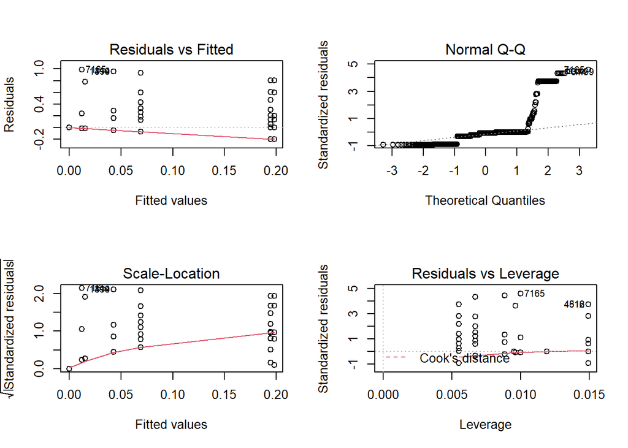

```r
par(mfrow = c(2,2))
plot(model_month)
```

### Evaluation of the models

We use **AIC** (Akaike Information Criterion) and **BIC** (Bayes Information Criterion) to evaluate the models we have created so far.

```r
# create a simple df
col_names = c("model", "AIC", "BIC")

models = c("distance", "species", "cumulative time", "cumulative time (poly of grade 2)", "cumulative time (poly of grade 3)", "month")
AIC = c(AIC(model_dist), AIC(model_species), AIC(model_time), AIC(model_time_poly2), AIC(model_time_poly3), AIC(model_month))
BIC = c(BIC(model_dist), BIC(model_species), BIC(model_time), BIC(model_time_poly2), BIC(model_time_poly3), BIC(model_month))

eval_df = data.frame(models, AIC, BIC)

datatable(eval_df, rownames = FALSE, class = 'cell-border stripe')
```

| models | AIC | BIC |
| --- | --- | --- |
| distance | -108.724349564856 | -94.0403394465557 |
| species | -162.499017403558 | -147.815007285258 |
| cumulative time | -189.89946801478 | -175.215457896479 |
| cumulative time (poly of grade 2) | -215.795860542602 | -196.217180384869 |
| cumulative time (poly of grade 3) | -220.364109110827 | -195.89075891366 |
| month | -213.011826687295 | -164.06512629296 |

We can see how the last polynomial models are the ones with better results, according to the metrics used.

### Experiments with Models

Now, we would like to fit a **full model**, using all the variables that are reasonable to use.

```r
model_exp_1 = lm(p_seed_rem~dist+species+month+tcum+available, data=df_clean)
summary(model_exp_1)
```

```
##
## Call:
## lm(formula = p_seed_rem ~ dist + species + month + tcum + available,
##     data = df_clean)
##
## Residuals:
##      Min       1Q   Median       3Q      Max
## -0.26714 -0.08784 -0.01301  0.01126  0.99377
##
## Coefficients:
##                  Estimate Std. Error t value Pr(>|t|)
## (Intercept)     0.2282928  0.0368637   6.193 8.70e-10 ***
## dist            0.0009188  0.0009324   0.985  0.32470
## speciespsd     -0.0957070  0.0200467  -4.774 2.08e-06 ***
## monthAugust    -0.1236306  0.1044712  -1.183  0.23694
## monthJuly      -0.1047271  0.0799284  -1.310  0.19042
## monthJune      -0.1402668  0.0583902  -2.402  0.01648 *
## monthMarch     -0.0111125  0.0333421  -0.333  0.73899
## monthMay       -0.1042009  0.0358869  -2.904  0.00377 **
## monthNovember  -0.1066854  0.1780151  -0.599  0.54911
## monthOctober   -0.1153076  0.1535510  -0.751  0.45287
## monthSeptember -0.1242076  0.1291668  -0.962  0.33649
## tcum           -0.0002838  0.0008063  -0.352  0.72498
## available       0.0038001  0.0063611   0.597  0.55039
## ---
## Signif. codes:  0 '***' 0.001 '**' 0.01 '*' 0.05 '.' 0.1 ' ' 1
##
## Residual standard error: 0.213 on 974 degrees of freedom
## Multiple R-squared:  0.1432, Adjusted R-squared:  0.1326
## F-statistic: 13.56 on 12 and 974 DF,  p-value: < 2.2e-16
```

**`## dist 0.0009188 0.0009324 0.985 0.32470`**

**`## speciespsd -0.0957070 0.0200467 -4.774 2.08e-06 ***`**

**`## monthJune -0.1402668 0.0583902 -2.402 0.01648 *`**

**`## monthMay -0.1042009 0.0358869 -2.904 0.00377 **`**

**`## tcum -0.0002838 0.0008063 -0.352 0.72498`**

**`## available 0.0038001 0.0063611 0.597 0.55039`**

Things are a little bit different with this model. What seems to be relavant are `species` and `month.`

#### Tweaking the model manually

We remove:

- the distance (`dist`)
- cumulative time (`tcum`)
- seeds availability (`available`)

and create another model.

```r
model_exp_2 = lm(p_seed_rem~species+month, data=df_clean)
summary(model_exp_2)
```

```
##
## Call:
## lm(formula = p_seed_rem ~ species + month, data = df_clean)
##
## Residuals:
##      Min       1Q   Median       3Q      Max
## -0.25056 -0.08794 -0.02558  0.01283  0.97442
##
## Coefficients:
##                 Estimate Std. Error t value Pr(>|t|)
## (Intercept)     0.250559   0.018814  13.318  < 2e-16 ***
## speciespsd     -0.089833   0.016308  -5.508 4.63e-08 ***
## monthAugust    -0.164396   0.026712  -6.154 1.10e-09 ***
## monthJuly      -0.135148   0.025689  -5.261 1.76e-07 ***
## monthJune      -0.162617   0.026360  -6.169 1.00e-09 ***
## monthMarch     -0.002941   0.030461  -0.097    0.923
## monthMay       -0.115603   0.023610  -4.896 1.14e-06 ***
## monthNovember  -0.173559   0.028356  -6.121 1.35e-09 ***
## monthOctober   -0.173559   0.026385  -6.578 7.77e-11 ***
## monthSeptember -0.173559   0.028356  -6.121 1.35e-09 ***
## ---
## Signif. codes:  0 '***' 0.001 '**' 0.01 '*' 0.05 '.' 0.1 ' ' 1
##
## Residual standard error: 0.2128 on 977 degrees of freedom
## Multiple R-squared:  0.1421, Adjusted R-squared:  0.1342
## F-statistic: 17.98 on 9 and 977 DF,  p-value: < 2.2e-16
```

#### Tweaking the model with STEP

Instead of doing it manually, let’s try to use `step`. This function takes away one variable from the model each time, choosing the one that decreases most AIC. It stops when taking away variables would only increase AIC.

```r
step(model_exp_1)
```

```
## Start:  AIC=-3039.45
## p_seed_rem ~ dist + species + month + tcum + available
##
##             Df Sum of Sq    RSS     AIC
## - tcum       1   0.00562 44.211 -3041.3
## - available  1   0.01620 44.222 -3041.1
## - dist       1   0.04406 44.250 -3040.5
## <none>                   44.205 -3039.4
## - month      8   1.29864 45.504 -3026.9
## - species    1   1.03447 45.240 -3018.6
##
## Step:  AIC=-3041.32
## p_seed_rem ~ dist + species + month + available
##
##             Df Sum of Sq    RSS     AIC
## - available  1    0.0178 44.229 -3042.9
## - dist       1    0.0419 44.253 -3042.4
## <none>                   44.211 -3041.3
## - species    1    1.0470 45.258 -3020.2
## - month      8    3.3267 47.538 -2985.7
##
## Step:  AIC=-3042.92
## p_seed_rem ~ dist + species + month
##
##           Df Sum of Sq    RSS     AIC
## - dist     1    0.0331 44.262 -3044.2
## <none>                 44.229 -3042.9
## - species  1    1.3400 45.569 -3015.5
## - month    8    4.4273 48.656 -2964.8
##
## Step:  AIC=-3044.18
## p_seed_rem ~ species + month
##
##           Df Sum of Sq    RSS     AIC
## <none>                 44.262 -3044.2
## - species  1    1.3747 45.637 -3016.0
## - month    8    4.4572 48.719 -2965.5
```

```
##
## Call:
## lm(formula = p_seed_rem ~ species + month, data = df_clean)
##
## Coefficients:
##    (Intercept)      speciespsd     monthAugust       monthJuly       monthJune
##       0.250559       -0.089833       -0.164396       -0.135148       -0.162617
##     monthMarch        monthMay   monthNovember    monthOctober  monthSeptember
##      -0.002941       -0.115603       -0.173559       -0.173559       -0.173559
```

We obtain the same results as what we did manually (`model_exp_2`).

Let’s plot the residuals.

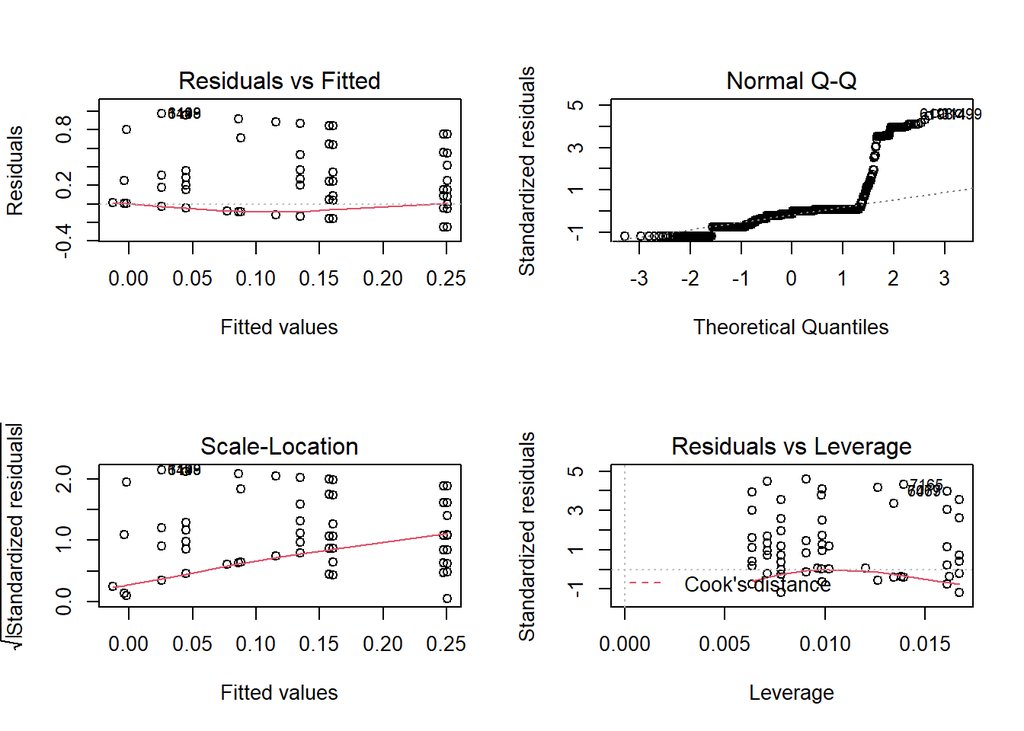

```r
par(mfrow = c(2,2))
plot(model_exp_2)
```

#### One last model

Finally, let’s try to create one last model, using `species` and `cumulative time` instead of `months`. This way we can use a **polynomial model**.

```r
model_exp_3 = lm(p_seed_rem~species+poly(tcum,3), data=df_clean)
summary(model_exp_3)
```

```
##
## Call:
## lm(formula = p_seed_rem ~ species + poly(tcum, 3), data = df_clean)
##
## Residuals:
##      Min       1Q   Median       3Q      Max
## -0.28490 -0.08824 -0.00497  0.00450  1.00387
##
## Coefficients:
##                Estimate Std. Error t value Pr(>|t|)
## (Intercept)     0.13563    0.01410   9.618  < 2e-16 ***
## speciespsd     -0.08982    0.01628  -5.516 4.42e-08 ***
## poly(tcum, 3)1 -1.80092    0.21738  -8.284 3.86e-16 ***
## poly(tcum, 3)2  1.03492    0.21360   4.845 1.47e-06 ***
## poly(tcum, 3)3 -0.51081    0.21273  -2.401   0.0165 *
## ---
## Signif. codes:  0 '***' 0.001 '**' 0.01 '*' 0.05 '.' 0.1 ' ' 1
##
## Residual standard error: 0.2126 on 982 degrees of freedom
## Multiple R-squared:  0.1397, Adjusted R-squared:  0.1362
## F-statistic: 39.87 on 4 and 982 DF,  p-value: < 2.2e-16
```

We plot the residuals.

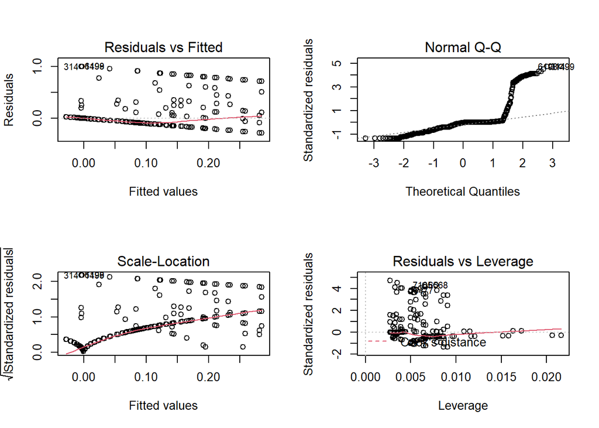

```r
par(mfrow = c(2,2))
plot(model_exp_3)
```

The plot of the residuals and the value of *R squared* are very similar. We can evaluate the models through AIC and BIC to understand which model is preferable.

#### Evaluation of the models

```r
# create a simple df
col_names = c("model", "AIC", "BIC")

models = c("distance", "species", "cumulative time", "cumulative time (poly of grade 2)", "cumulative time (poly of grade 3)", "month", "species + month", "species + cumulative time (poly of grade 3)")
AIC = c(AIC(model_dist), AIC(model_species), AIC(model_time), AIC(model_time_poly2), AIC(model_time_poly3), AIC(model_month), AIC(model_exp_2), AIC(model_exp_3))
BIC = c(BIC(model_dist), BIC(model_species), BIC(model_time), BIC(model_time_poly2), BIC(model_time_poly3), BIC(model_month), BIC(model_exp_2), BIC(model_exp_3))

eval_df = data.frame(models, AIC, BIC)

datatable(eval_df, rownames = FALSE, class = 'cell-border stripe')
```

| models | AIC | BIC |
| --- | --- | --- |
| distance | -108.724349564856 | -94.0403394465557 |
| species | -162.499017403558 | -147.815007285258 |
| cumulative time | -189.89946801478 | -175.215457896479 |
| cumulative time (poly of grade 2) | -215.795860542602 | -196.217180384869 |
| cumulative time (poly of grade 3) | -220.364109110827 | -195.89075891366 |
| month | -213.011826687295 | -164.06512629296 |
| species + month | -241.198885015179 | -187.357514581411 |
| species + cumulative time (poly of grade 3) | -248.485950276483 | -219.117930039882 |

According to the metrics, the best model is one that uses `species` and `cumulative time` (with a polynomial). This is an example of how the `step` function is not perfect, and better results can be obtained through more advanced analysis.